# Predict bankrupt in the subsequent years or not.

Broto

20 June 2018

**NOTE** Clear the environment

```r
rm(list = ls(all=TRUE))
```

## Goal

- Based on various financial ratios , predict whether the company got bankrupt in the subsequent years or not.

## Agenda

- Get the data
- Data Pre-processing
- Build a model
- Predictions
- Communication

### Libraries used

```r
library(ROSE)
```

```r
library(corrplot)
library(caret)
library(C50)
library(rpart)
library(rpart.plot)
library(DMwR)
library(class)
library(mice)
library(vegan)
library(randomForest)
library(inTrees)
library(e1071)
```

## Reading & Understanding the Data

### Read the Data

```r
setwd("C://Users//brbhatta//Desktop//INSOFE//Cute3")
bank_data <- read.csv("train.csv")
```

### Understand the data

```r
str(bank_data)
```

```
## 'data.frame':    36553 obs. of  66 variables:
##  $ ID    : int  1 2 3 4 5 6 7 8 9 10 ...
##  $ Attr1 : num  0.13537 0.00586 0.1106 0.06391 0.13168 ...
##  $ Attr2 : num  0.452 0.399 0.161 1.407 0.66 ...
##  $ Attr3 : num  0.312 0.198 0.479 -0.296 0.441 ...
##  $ Attr4 : num  2.047 1.939 7.571 0.529 2.71 ...
##  $ Attr5 : num  10.23 9.58 263.9 -46.29 -23.6 ...
##  $ Attr6 : num  0.168 0 0 -0.714 -0.2 ...
##  $ Attr7 : num  0.16763 0.00724 0.13836 0.07907 0.13191 ...
##  $ Attr8 : num  1.213 1.509 5.205 -0.331 0.514 ...
##  $ Attr9 : num  2.255 0.979 0.684 0.985 2.136 ...
##  $ Attr10: num  0.548 0.601 0.839 -0.465 0.34 ...
##  $ Attr11: num  0.1833 0.0295 0.1388 0.0791 0.1861 ...
##  $ Attr12: num  0.5632 0.0344 1.8983 0.1258 0.5112 ...
##  $ Attr13: num  0.0892 0.0364 0.2362 0.0303 0.1671 ...
```

[output cut: 52 more lines]

```r
summary(bank_data)
```

```
##        ID            Attr1                Attr2
##  Min.   :    1   Min.   :-256.89000   Min.   :-430.8700
##  1st Qu.: 9139   1st Qu.:   0.00334   1st Qu.:   0.2696
##  Median :18277   Median :   0.04960   Median :   0.4726
##  Mean   :18277   Mean   :   0.05146   Mean   :   0.5777
##  3rd Qu.:27415   3rd Qu.:   0.13008   3rd Qu.:   0.6892
##  Max.   :36553   Max.   :  94.28000   Max.   : 480.9600
##                  NA's   :8            NA's   :8
##      Attr3               Attr4              Attr5
##  Min.   :-479.9600   Min.   :   -0.05   Min.   :-11903000
##  1st Qu.:   0.0221   1st Qu.:    1.05   1st Qu.:      -49
##  Median :   0.1975   Median :    1.57   Median :       -1
##  Mean   :   0.1274   Mean   :    6.84   Mean   :     -482
##  3rd Qu.:   0.4048   3rd Qu.:    2.79   3rd Qu.:       51
##  Max.   :  28.3360   Max.   :53433.00   Max.   :  1034100
##  NA's   :8           NA's   :111        NA's   :76
##      Attr6               Attr7               Attr8
##  Min.   :-508.4100   Min.   :-517.4800   Min.   : -141.41
##  1st Qu.:   0.0000   1st Qu.:   0.0057   1st Qu.:    0.43
##  Median :   0.0000   Median :   0.0595   Median :    1.07
##  Mean   :  -0.0309   Mean   :   0.1151   Mean   :   12.91
##  3rd Qu.:   0.0869   3rd Qu.:   0.1517   3rd Qu.:    2.61
##  Max.   : 543.2500   Max.   : 649.2300   Max.   :53432.00
##  NA's   :8           NA's   :8           NA's   :79
##      Attr9              Attr10              Attr11
##  Min.   :  -3.496   Min.   :-479.9100   Min.   :-189.4500
##  1st Qu.:   1.019   1st Qu.:   0.2948   1st Qu.:   0.0153
##  Median :   1.200   Median :   0.5056   Median :   0.0754
##  Mean   :   2.675   Mean   :   0.6496   Mean   :   0.1549
##  3rd Qu.:   2.063   3rd Qu.:   0.7084   3rd Qu.:   0.1678
##  Max.   :9742.300   Max.   :1099.5000   Max.   : 681.5400
##  NA's   :7          NA's   :8           NA's   :37
##      Attr12              Attr13              Attr14
##  Min.   :-6331.800   Min.   :-1317.600   Min.   :-517.4800
##  1st Qu.:    0.015   1st Qu.:    0.024   1st Qu.:   0.0057
##  Median :    0.171   Median :    0.068   Median :   0.0596
##  Mean   :    1.182   Mean   :    0.956   Mean   :   0.1152
##  3rd Qu.:    0.586   3rd Qu.:    0.135   3rd Qu.:   0.1517
##  Max.   : 8259.400   Max.   :13315.000   Max.   : 649.2300
##  NA's   :111         NA's   :113         NA's   :8
```

[output cut: 121 more lines]

```
##  Min.   :    -12   Min.   :   -12.66   Min.   :  -14965
##  1st Qu.:      6   1st Qu.:     4.51   1st Qu.:      42
##  Median :     10   Median :     6.63   Median :      71
##  Mean   :    482   Mean   :    17.68   Mean   :    1784
##  3rd Qu.:     20   3rd Qu.:    10.38   3rd Qu.:     117
##  Max.   :4818700   Max.   :108000.00   Max.   :25016000
##  NA's   :1833      NA's   :86          NA's   :113
##      Attr63              Attr64              target
##  Min.   :   -0.368   Min.   :    -3.73   Min.   :0.00000
##  1st Qu.:    3.099   1st Qu.:     2.19   1st Qu.:0.00000
##  Median :    5.079   Median :     4.31   Median :0.00000
##  Mean   :    9.417   Mean   :    77.35   Mean   :0.04829
##  3rd Qu.:    8.607   3rd Qu.:     9.79   3rd Qu.:0.00000
##  Max.   :23454.000   Max.   :294770.00   Max.   :1.00000
##  NA's   :111         NA's   :694
```

```r
head(bank_data)
```

```
##   ID     Attr1    Attr2    Attr3   Attr4    Attr5    Attr6     Attr7
## 1  1 0.1353700 0.451850  0.31162  2.0469  10.2340  0.16768 0.1676300
## 2  2 0.0058613 0.398580  0.19768  1.9390   9.5771  0.00000 0.0072373
## 3  3 0.1106000 0.161170  0.47894  7.5711 263.9000  0.00000 0.1383600
## 4  4 0.0639110 1.407300 -0.29595  0.5291 -46.2870 -0.71420 0.0790710
## 5  5 0.1316800 0.660310  0.44121  2.7098 -23.5960 -0.20007 0.1319100
## 6  6 0.2541100 0.022149  0.69694 33.2270  86.6400  0.00000 0.2541100
##      Attr8   Attr9   Attr10   Attr11   Attr12   Attr13    Attr14   Attr15
## 1  1.21310 2.25540  0.54815 0.183310  0.56316 0.089220 0.1676300  819.600
## 2  1.50890 0.97880  0.60142 0.029484  0.03438 0.036362 0.0072373 4087.600
## 3  5.20450 0.68447  0.83883 0.138830  1.89830 0.236220 0.1383600  363.850
## 4 -0.33076 0.98490 -0.46548 0.079071  0.12581 0.030274 0.0790710 5433.400
## 5  0.51445 2.13570  0.33969 0.186110  0.51117 0.167100 0.1319100  675.350
## 6 44.14900 1.97160  0.97785 0.264670 11.75000 0.150150 0.2541100   27.309
##      Attr16   Attr17    Attr18    Attr19 Attr20  Attr21    Attr22
```

[output cut: 48 more lines]

```r
tail(bank_data)
```

```
##          ID     Attr1   Attr2     Attr3   Attr4    Attr5      Attr6
## 36548 36548 -0.117490 1.10800 -0.224310 0.79755 -201.640 -0.0593250
## 36549 36549  0.425980 0.18731  0.361740 3.00860   50.257  1.2929000
## 36550 36550 -0.016238 0.43902  0.069466 1.16780 -191.590  0.0045487
## 36551 36551  0.073750 0.18138  0.219690 3.50200   66.436  0.1694200
## 36552 36552 -0.871080 1.16990 -0.187060 0.84010  -62.657 -0.0281450
## 36553 36553  0.063897 0.84939  0.285080 1.55680   -3.031 -0.1169200
##           Attr7     Attr8   Attr9   Attr10    Attr11    Attr12    Attr13
## 36548 -0.117490 -0.097464 0.92515 -0.10799 -0.117490 -0.106040 -0.062038
## 36549  0.425980  3.967200 1.38350  0.74311  0.425980  2.365200  0.358000
## 36550 -0.021788  1.108500 0.94926  0.48663 -0.021788 -0.052624  0.052201
## 36551  0.092655  4.513200 1.09190  0.81862  0.092655  1.055300  0.247430
## 36552 -0.871080 -0.145210 1.89250 -0.16988 -0.643470 -0.744590 -0.460280
## 36553  0.083468  0.177310 4.83790  0.15060  0.114700  0.163030  0.022181
##          Attr14   Attr15    Attr16  Attr17    Attr18    Attr19  Attr20
```

[output cut: 55 more lines]

### Data Description

Attr1 net profit / total assets Attr2 total liabilities / total assets Attr3 working capital / total assets Attr4 current assets / short-term liabilities Attr5 [(cash + short-term securities + receivables - short-term liabilities) / (operating expenses - depreciation)] * 365 Attr6 retained earnings / total assets Attr7 EBIT / total assets Attr8 book value of equity / total liabilities Attr9 sales / total assets Attr10 equity / total assets Attr11 (gross profit + extraordinary items + financial expenses) / total assets Attr12 gross profit / short-term liabilities Attr13 (gross profit + depreciation) / sales Attr14 (gross profit + interest) / total assets Attr15 (total liabilities * 365) / (gross profit + depreciation) Attr16 (gross profit + depreciation) / total liabilities Attr17 total assets / total liabilities Attr18 gross profit / total assets Attr19 gross profit / sales Attr20 (inventory * 365) / sales Attr21 sales (n) / sales (n-1) Attr22 profit on operating activities / total assets Attr23 net profit / sales Attr24 gross profit (in 3 years) / total assets Attr25 (equity - share capital) / total assets Attr26 (net profit + depreciation) / total liabilities Attr27 profit on operating activities / financial expenses Attr28 working capital / fixed assets Attr29 logarithm of total assets Attr30 (total liabilities - cash) / sales Attr31 (gross profit + interest) / sales Attr32 (current liabilities * 365) / cost of products sold Attr33 operating expenses / short-term liabilities Attr34 operating expenses / total liabilities Attr35 profit on sales / total assets Attr36 total sales / total assets Attr37 (current assets - inventories) / long-term liabilities Attr38 constant capital / total assets Attr39 profit on sales / sales Attr40 (current assets - inventory - receivables) / short-term liabilities Attr41 total liabilities / ((profit on operating activities + depreciation) * (12/365)) Attr42 profit on operating activities / sales Attr43 rotation receivables + inventory turnover in days Attr44 (receivables * 365) / sales Attr45 net profit / inventory Attr46 (current assets - inventory) / short-term liabilities Attr47 (inventory * 365) / cost of products sold Attr48 EBITDA (profit on operating activities - depreciation) / total assets Attr49 EBITDA (profit on operating activities - depreciation) / sales Attr50 current assets / total liabilities Attr51 short-term liabilities / total assets Attr52 (short-term liabilities * 365) / cost of products sold) Attr53 equity / fixed assets Attr54 constant capital / fixed assets Attr55 working capital Attr56 (sales - cost of products sold) / sales Attr57 (current assets - inventory - short-term liabilities) / (sales - gross profit - depreciation) Attr58 total costs /total sales Attr59 long-term liabilities / equity Attr60 sales / inventory Attr61 sales / receivables Attr62 (short-term liabilities *365) / sales Attr63 sales / short-term liabilities Attr64 sales / fixed assets

# Verify the data types assigned to the variables in the dataset

```r
str(bank_data)
```

```
## 'data.frame':    36553 obs. of  66 variables:
##  $ ID    : int  1 2 3 4 5 6 7 8 9 10 ...
##  $ Attr1 : num  0.13537 0.00586 0.1106 0.06391 0.13168 ...
##  $ Attr2 : num  0.452 0.399 0.161 1.407 0.66 ...
##  $ Attr3 : num  0.312 0.198 0.479 -0.296 0.441 ...
##  $ Attr4 : num  2.047 1.939 7.571 0.529 2.71 ...
##  $ Attr5 : num  10.23 9.58 263.9 -46.29 -23.6 ...
##  $ Attr6 : num  0.168 0 0 -0.714 -0.2 ...
##  $ Attr7 : num  0.16763 0.00724 0.13836 0.07907 0.13191 ...
##  $ Attr8 : num  1.213 1.509 5.205 -0.331 0.514 ...
##  $ Attr9 : num  2.255 0.979 0.684 0.985 2.136 ...
##  $ Attr10: num  0.548 0.601 0.839 -0.465 0.34 ...
##  $ Attr11: num  0.1833 0.0295 0.1388 0.0791 0.1861 ...
##  $ Attr12: num  0.5632 0.0344 1.8983 0.1258 0.5112 ...
##  $ Attr13: num  0.0892 0.0364 0.2362 0.0303 0.1671 ...
```

[output cut: 52 more lines]

# Plot the data to understand

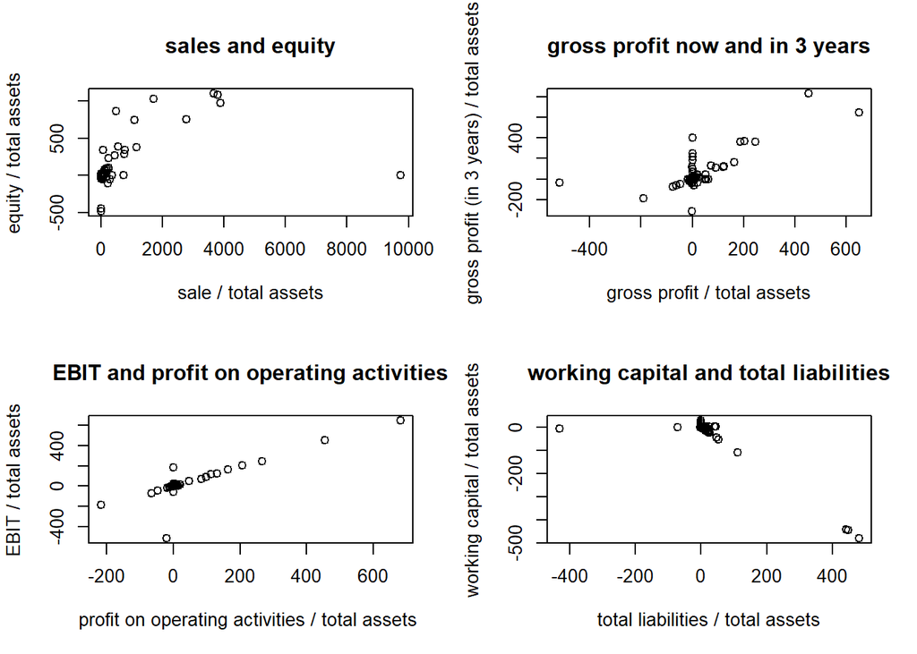

```r
par(mfrow = c(2,2))

plot(bank_data[,"Attr9"],bank_data[,"Attr10"],xlab="sale / total assets",ylab="equity / total assets",type="p",main="sales and equity" )
plot(bank_data[,"Attr18"],bank_data[,"Attr24"],xlab="gross profit / total assets",ylab="gross profit (in 3 years) / total assets",type="p",main="gross profit now and in 3 years" )
plot(bank_data[,"Attr22"],bank_data[,"Attr7"],xlab="profit on operating activities / total assets ",ylab="EBIT / total assets",type="p",main="EBIT and profit on operating activities" )
plot(bank_data[,"Attr2"],bank_data[,"Attr3"],xlab="total liabilities / total assets",ylab="working capital / total assets",type="p",main="working capital and total liabilities" )
```

# Substracting current gross income from gross income in 3 years

```r
str(bank_data)
```

```
## 'data.frame':    36553 obs. of  66 variables:
##  $ ID    : int  1 2 3 4 5 6 7 8 9 10 ...
##  $ Attr1 : num  0.13537 0.00586 0.1106 0.06391 0.13168 ...
##  $ Attr2 : num  0.452 0.399 0.161 1.407 0.66 ...
##  $ Attr3 : num  0.312 0.198 0.479 -0.296 0.441 ...
##  $ Attr4 : num  2.047 1.939 7.571 0.529 2.71 ...
##  $ Attr5 : num  10.23 9.58 263.9 -46.29 -23.6 ...
##  $ Attr6 : num  0.168 0 0 -0.714 -0.2 ...
##  $ Attr7 : num  0.16763 0.00724 0.13836 0.07907 0.13191 ...
##  $ Attr8 : num  1.213 1.509 5.205 -0.331 0.514 ...
##  $ Attr9 : num  2.255 0.979 0.684 0.985 2.136 ...
##  $ Attr10: num  0.548 0.601 0.839 -0.465 0.34 ...
##  $ Attr11: num  0.1833 0.0295 0.1388 0.0791 0.1861 ...
##  $ Attr12: num  0.5632 0.0344 1.8983 0.1258 0.5112 ...
##  $ Attr13: num  0.0892 0.0364 0.2362 0.0303 0.1671 ...
```

[output cut: 52 more lines]

```r
bank_data1= cbind(bank_data,data.frame(bank_data$Attr24-bank_data$Attr18))
```

# Check for missing values

```r
sum(is.na(bank_data))
```

```
## [1] 35187
```

```r
bank_data=centralImputation(bank_data)
sum(is.na(bank_data))
```

```
## [1] 0
```

### Check for class imbalance

```r
prop.table(table(bank_data$target))
```

```
##
##          0          1
## 0.95171395 0.04828605
```

```r
bank_data_rose <- ROSE(target~ ., data=bank_data, seed=111)$data
prop.table(table(bank_data_rose$target))
```

```
##
##        0        1
## 0.500807 0.499193
```

# Find the corelation between the features.

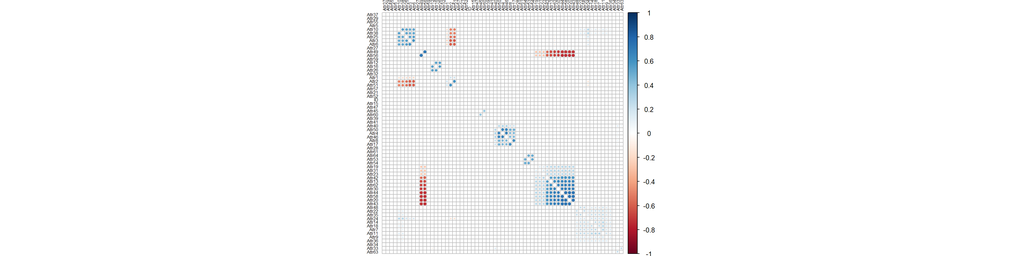

```r
cat_var="target"
num_var=setdiff(names(bank_data),cat_var)
corrplot( cor(bank_data_rose[,num_var]), method="circle", tl.cex = 0.5, tl.col = 'black',  order = "hclust", diag = FALSE)
```

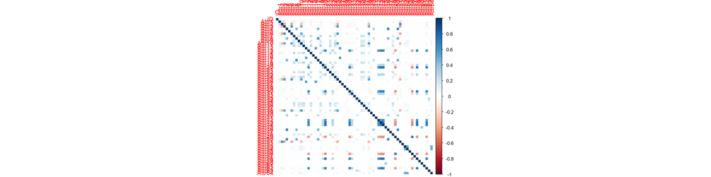

```r
corrplot(cor(bank_data_rose[,num_var]), method="shade",type = "full")
```

# Split the Data into train and test sets

- Use stratified sampling to split the data into train/test sets (70/30)
- Use the createDataPartition() function from the caret package to do stratified sampling

```r
# Set the seed after attaching the caret package

set.seed(111)

# The first argument is the imbalanced class reference variable, the second is the proportion to sample

# Remember to include list = F as the function returns a list otherwise which would not be able to subset a dataframe

trainIndex <- createDataPartition(bank_data$target, p = .7, list = F)

train_data <- bank_data[trainIndex, ]

test_data <- bank_data[-trainIndex, ]
```

## Build a Decision Tree

### Model the tree

- We will be using Quinlan’s C5.0 decision tree algorithm implementation from the C50 package to build our decision tree

```r
train_data$target<-as.factor(train_data$target)
test_data$target<-as.factor(test_data$target)
str(train_data$target)
```

```
##  Factor w/ 2 levels "0","1": 1 1 1 1 1 1 1 1 1 1 ...
```

```r
c5_tree <- C5.0(target ~ . , train_data)

# Use the rules = T argument if you want to extract rules later from the model

c5_rules <- C5.0(target ~ . , train_data, rules = T)
```

### Variable Importance in trees

- Find the importance of each variable in the dataset using the c5imp() function
- The default metric “usage” in the c5imp function gives the percentage of data being split by using the attribute at that particular time. So variable used for splitting at the root node always has 100, and the variables at the leaf nodes might be close to 0 if there is no data remaining to classify

```r
C5imp(c5_tree, metric = "usage")
```

```
##        Overall
## Attr41  100.00
## Attr27   98.93
## Attr46   93.18
## Attr24   72.54
## Attr34   27.54
## Attr5    23.10
## Attr56   11.09
## Attr58    9.90
## Attr35    9.74
## Attr8     6.68
## Attr60    6.53
## Attr42    5.26
## Attr9     4.40
## Attr6     2.86
## Attr15    2.78
## Attr25    1.73
## Attr44    1.15
## Attr23    0.50
## Attr22    0.42
## Attr13    0.35
## Attr39    0.28
## Attr19    0.25
## Attr48    0.19
## Attr38    0.16
## Attr53    0.16
## Attr64    0.13
## Attr29    0.05
## ID        0.00
## Attr1     0.00
## Attr2     0.00
## Attr3     0.00
## Attr4     0.00
## Attr7     0.00
## Attr10    0.00
## Attr11    0.00
## Attr12    0.00
## Attr14    0.00
## Attr16    0.00
## Attr17    0.00
```

[output cut: 11 more lines]

```
## Attr40    0.00
## Attr43    0.00
## Attr45    0.00
## Attr47    0.00
## Attr49    0.00
## Attr50    0.00
## Attr51    0.00
## Attr52    0.00
## Attr54    0.00
## Attr55    0.00
## Attr57    0.00
## Attr59    0.00
## Attr61    0.00
## Attr62    0.00
## Attr63    0.00
```

### Rules from trees

- Understand the summary of the returned c5.0 rules based on the decision tree model

```r
summary(c5_rules)
```

```
##
## Call:
## C5.0.formula(formula = target ~ ., data = train_data, rules = T)
##
##
## C5.0 [Release 2.07 GPL Edition]      Fri Jun 22 21:28:43 2018
## -------------------------------
##
## Class specified by attribute `outcome'
##
## Read 25588 cases (66 attributes) from undefined.data
##
## Rules:
##
## Rule 1: (1868, lift 1.0)
##  Attr27 <= 0.87682
##  Attr34 <= 0.078963
##  Attr46 > 0.5449
##  ->  class 0  [0.999]
##
## Rule 2: (174, lift 1.0)
##  Attr5 > -22.458
##  Attr5 <= 82.901
##  Attr41 > -0.000156
##  Attr58 <= 0.34016
##  ->  class 0  [0.994]
##
## Rule 3: (592/7, lift 1.0)
##  Attr34 <= 0.22583
##  Attr41 > -0.000156
##  Attr46 > 0.5449
##  Attr56 > 0.068701
##  ->  class 0  [0.987]
##
## Rule 4: (8685/121, lift 1.0)
##  Attr27 <= 0.96568
##  Attr41 > -0.000156
##  ->  class 0  [0.986]
##
## Rule 5: (623/9, lift 1.0)
```

[output cut: 196 more lines]

```
##   12.80% Attr5
##    3.75% Attr58
##    2.72% Attr56
##    1.72% Attr24
##    0.62% Attr35
##    0.48% Attr44
##    0.35% Attr6
##    0.13% Attr23
##    0.13% Attr53
##    0.11% Attr64
##    0.06% Attr39
##    0.03% Attr29
##
##
## Time: 6.7 secs
```

- From the output of the summary above, you can clearly understand the rules and their associated metrics such as lift and support
- **This is great for explicability and can also be used for understanding interesting relationships in data, even if your final model is not a decision tree**

### Plotting the tree

- Call the plot function on the tree object to visualize the tree

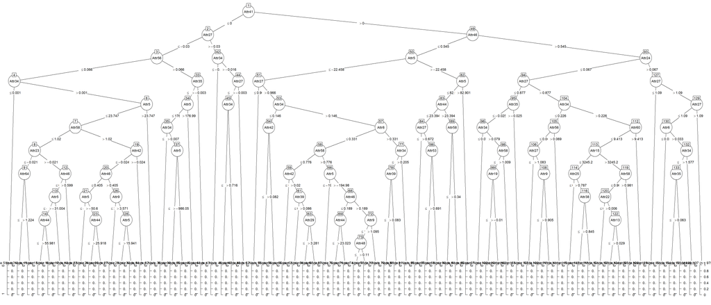

```r
plot(c5_tree)
```

## Evaluating the model

### Predictions on the test data

- We’ll evaluate the decision tree using the standard error metrics on test data

```r
preds <- predict(c5_tree, train_data)
preds1 <- predict(c5_tree, test_data)
```

- Error metrics for classification can be accessed through the “confusionMatrix()” function from the caret package

```r
conf_train=confusionMatrix(preds, train_data$target, positive = "0")
conf_test=confusionMatrix(preds1, test_data$target, positive = "0")
conf_train
```

```
## Confusion Matrix and Statistics
##
##           Reference
## Prediction     0     1
##          0 24342   632
##          1    23   591
##
##                Accuracy : 0.9744
##                  95% CI : (0.9724, 0.9763)
##     No Information Rate : 0.9522
##     P-Value [Acc > NIR] : < 2.2e-16
##
##                   Kappa : 0.6317
##  Mcnemar's Test P-Value : < 2.2e-16
##
##             Sensitivity : 0.9991
##             Specificity : 0.4832
##          Pos Pred Value : 0.9747
##          Neg Pred Value : 0.9625
##              Prevalence : 0.9522
##          Detection Rate : 0.9513
##    Detection Prevalence : 0.9760
##       Balanced Accuracy : 0.7411
##
##        'Positive' Class : 0
##
```

```r
conf_test
```

```
## Confusion Matrix and Statistics
##
##           Reference
## Prediction     0     1
##          0 10384   301
##          1    39   241
##
##                Accuracy : 0.969
##                  95% CI : (0.9656, 0.9722)
##     No Information Rate : 0.9506
##     P-Value [Acc > NIR] : < 2.2e-16
##
##                   Kappa : 0.572
##  Mcnemar's Test P-Value : < 2.2e-16
##
##             Sensitivity : 0.9963
##             Specificity : 0.4446
##          Pos Pred Value : 0.9718
##          Neg Pred Value : 0.8607
##              Prevalence : 0.9506
##          Detection Rate : 0.9470
##    Detection Prevalence : 0.9745
##       Balanced Accuracy : 0.7205
##
##        'Positive' Class : 0
##
```

# Finding the F1 score since it is very important to have high precision and recall for this problem

# Print F1 score

```r
F1_score<-function(Recall, Precision)   {
     F1<-2*Recall*Precision/(Recall+Precision)
     return(F1)
}

recall_test <- sensitivity(preds1, test_data$target)
precision_test <- posPredValue(preds1, test_data$target)

F1_model_c5<-F1_score(recall_test,precision_test)

print(F1_model_c5)
```

```
## [1] 0.9838924
```

# CART Trees

- The classification and regression trees use gini index in place of the gain ratio (based on information gain) used by the ID3 based algorithms, such as c4.5 and c5.0

## Goal

```r
reg_tree <- rpart(target ~ ., train_data,method='class')

printcp(reg_tree)
```

```
##
## Classification tree:
## rpart(formula = target ~ ., data = train_data, method = "class")
##
## Variables actually used in tree construction:
## [1] Attr24 Attr27 Attr34 Attr35 Attr56
##
## Root node error: 1223/25588 = 0.047796
##
## n= 25588
##
##         CP nsplit rel error  xerror     xstd
## 1 0.027187      0   1.00000 1.00000 0.027903
## 2 0.024530      4   0.89125 0.92723 0.026918
## 3 0.010000      8   0.79313 0.80948 0.025225
```

### Tree Explicability

- The variable importance can accessed accessing variable.importance from the reg.tree list

```r
reg_tree$variable.importance
```

```
##      Attr34      Attr56      Attr39      Attr41      Attr35      Attr22
## 266.0787251 175.2489122  86.2233824  71.8981654  69.5123896  65.9275392
##      Attr55      Attr58      Attr27      Attr42      Attr33      Attr29
##  63.1595004  60.1780071  59.7002362  56.7521977  55.7751874  48.6854482
##       Attr9      Attr36      Attr15      Attr14      Attr18       Attr7
##  42.9363953  31.9695663  30.2639273  24.7714078  24.7714078  24.7634139
##      Attr24      Attr19      Attr52      Attr30      Attr32      Attr12
##  21.1439300  19.7373439  12.0567802  11.0083645  10.9527372   6.9107476
##       Attr1      Attr48      Attr11      Attr47      Attr10      Attr25
##   6.5390301   5.7424230   5.4991000   0.9371612   0.4685806   0.4685806
```

- We can plot the regression tree using the rpart.plot() function from the rpart.plot package

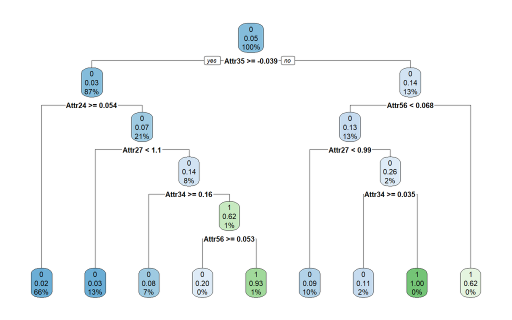

```r
rpart.plot(reg_tree)
```

## Evaluating the model

### Predictions on the test data

- We’ll evaluate the decision tree using the standard error metrics on test data

```r
summary(reg_tree) # detailed summary of splits
```

```
## Call:
## rpart(formula = target ~ ., data = train_data, method = "class")
##   n= 25588
##
##           CP nsplit rel error    xerror       xstd
## 1 0.02718724      0 1.0000000 1.0000000 0.02790306
## 2 0.02452984      4 0.8912510 0.9272281 0.02691763
## 3 0.01000000      8 0.7931316 0.8094849 0.02522452
##
## Variable importance
## Attr34 Attr56 Attr39 Attr41 Attr35 Attr22 Attr55 Attr58 Attr27 Attr42
##     20     13      6      5      5      5      5      4      4      4
## Attr33 Attr29  Attr9 Attr36 Attr15 Attr14 Attr18  Attr7 Attr24 Attr19
##      4      4      3      2      2      2      2      2      2      1
## Attr52 Attr30 Attr32 Attr12
##      1      1      1      1
##
## Node number 1: 25588 observations,    complexity param=0.02718724
##   predicted class=0  expected loss=0.04779584  P(node) =1
##     class counts: 24365  1223
##    probabilities: 0.952 0.048
##   left son=2 (22195 obs) right son=3 (3393 obs)
##   Primary splits:
##       Attr35 < -0.0393365   to the right, improve=69.51239, (0 missing)
##       Attr39 < -0.035456    to the right, improve=69.15036, (0 missing)
##       Attr41 < -0.0128205   to the right, improve=67.27618, (0 missing)
##       Attr26 < 0.032943     to the right, improve=63.03163, (0 missing)
##       Attr24 < 0.053813     to the right, improve=62.76884, (0 missing)
##   Surrogate splits:
##       Attr39 < -0.0238625   to the right, agree=0.974, adj=0.808, (0 split)
##       Attr22 < -0.0393375   to the right, agree=0.967, adj=0.749, (0 split)
##       Attr56 < -0.021217    to the right, agree=0.956, adj=0.665, (0 split)
##       Attr42 < -0.019477    to the right, agree=0.950, adj=0.625, (0 split)
##       Attr41 < -0.000131595 to the right, agree=0.944, adj=0.580, (0 split)
##
## Node number 2: 22195 observations,    complexity param=0.02452984
##   predicted class=0  expected loss=0.0333859  P(node) =0.8673988
##     class counts: 21454   741
##    probabilities: 0.967 0.033
##   left son=4 (16905 obs) right son=5 (5290 obs)
```

[output cut: 150 more lines]

```
##
## Node number 27: 107 observations
##   predicted class=1  expected loss=0  P(node) =0.004181648
##     class counts:     0   107
##    probabilities: 0.000 1.000
##
## Node number 46: 101 observations
##   predicted class=0  expected loss=0.1980198  P(node) =0.003947163
##     class counts:    81    20
##    probabilities: 0.802 0.198
##
## Node number 47: 138 observations
##   predicted class=1  expected loss=0.06521739  P(node) =0.005393153
##     class counts:     9   129
##    probabilities: 0.065 0.935
```

```r
pred2 = predict(reg_tree, train_data,type = "class")
pred3 = predict(reg_tree, test_data,type = "class")

table(pred2, train_data$target)
```

```
##
## pred2     0     1
##     0 24314   919
##     1    51   304
```

```r
table(pred3, test_data$target)
```

```
##
## pred3     0     1
##     0 10397   401
##     1    26   141
```

# Error metrics for classification can be accessed through the “confusionMatrix()” function from the caret package

```r
conf_train=confusionMatrix(pred2, train_data$target, positive = "0")
conf_test=confusionMatrix(pred3, test_data$target, positive = "0")
conf_train
```

```
## Confusion Matrix and Statistics
##
##           Reference
## Prediction     0     1
##          0 24314   919
##          1    51   304
##
##                Accuracy : 0.9621
##                  95% CI : (0.9597, 0.9644)
##     No Information Rate : 0.9522
##     P-Value [Acc > NIR] : 9.278e-15
##
##                   Kappa : 0.3718
##  Mcnemar's Test P-Value : < 2.2e-16
##
##             Sensitivity : 0.9979
##             Specificity : 0.2486
##          Pos Pred Value : 0.9636
##          Neg Pred Value : 0.8563
##              Prevalence : 0.9522
##          Detection Rate : 0.9502
##    Detection Prevalence : 0.9861
##       Balanced Accuracy : 0.6232
##
##        'Positive' Class : 0
##
```

```r
conf_test
```

```
## Confusion Matrix and Statistics
##
##           Reference
## Prediction     0     1
##          0 10397   401
##          1    26   141
##
##                Accuracy : 0.9611
##                  95% CI : (0.9573, 0.9646)
##     No Information Rate : 0.9506
##     P-Value [Acc > NIR] : 8.803e-08
##
##                   Kappa : 0.3834
##  Mcnemar's Test P-Value : < 2.2e-16
##
##             Sensitivity : 0.9975
##             Specificity : 0.2601
##          Pos Pred Value : 0.9629
##          Neg Pred Value : 0.8443
##              Prevalence : 0.9506
##          Detection Rate : 0.9482
##    Detection Prevalence : 0.9848
##       Balanced Accuracy : 0.6288
##
##        'Positive' Class : 0
##
```

# Finding the F1 score since it is very important to have high precision and recall for this problem

# Print F1 score

```r
recall_test <- sensitivity(pred3, test_data$target)
precision_test <- posPredValue(pred3, test_data$target)

F1_model_rpart<-F1_score(recall_test,precision_test)

print(F1_model_rpart)
```

```
## [1] 0.9798784
```

# Build KNN model

```r
  # N = 1/3/5/7
  Neigh <-3
  pred=knn(train_data[,num_var], test_data[,num_var],train_data$target , k = Neigh)
  a=table(pred,test_data$target)
```

# Error metrics for classification can be accessed through the “confusionMatrix()” function from the caret package

```r
conf_test=confusionMatrix(pred, test_data$target, positive = "0")
conf_test
```

```
## Confusion Matrix and Statistics
##
##           Reference
## Prediction     0     1
##          0 10318   528
##          1   105    14
##
##                Accuracy : 0.9423
##                  95% CI : (0.9377, 0.9466)
##     No Information Rate : 0.9506
##     P-Value [Acc > NIR] : 1
##
##                   Kappa : 0.025
##  Mcnemar's Test P-Value : <2e-16
##
##             Sensitivity : 0.98993
##             Specificity : 0.02583
##          Pos Pred Value : 0.95132
##          Neg Pred Value : 0.11765
##              Prevalence : 0.95057
##          Detection Rate : 0.94099
##    Detection Prevalence : 0.98915
##       Balanced Accuracy : 0.50788
##
##        'Positive' Class : 0
##
```

# Finding the F1 score since it is very important to have high precision and recall for this problem

# Print F1 score

```r
recall_test <- sensitivity(pred, test_data$target)
precision_test <- posPredValue(pred, test_data$target)

F1_model_knn<-F1_score(recall_test,precision_test)

print(F1_model_knn)
```

```
## [1] 0.9702384
```

```r
accu= sum(diag(a))/sum(a)
accu
```

```
## [1] 0.9422709
```

# Model Building using Random Forest and tuning

```r
# Build the classification model using randomForest
model = randomForest(target ~ ., data=train_data,
                      keep.forest=TRUE, ntree=50)

# Print and understand the model
print(model)
```

```
##
## Call:
##  randomForest(formula = target ~ ., data = train_data, keep.forest = TRUE,      ntree = 50)
##                Type of random forest: classification
##                      Number of trees: 50
## No. of variables tried at each split: 8
##
##         OOB estimate of  error rate: 4.13%
## Confusion matrix:
##       0   1 class.error
## 0 24280  85 0.003488611
## 1   971 252 0.793949305
```

# Important attributes

```r
model$importance
```

```
##        MeanDecreaseGini
## ID             40.18912
## Attr1          26.56679
## Attr2          22.61744
## Attr3          29.02045
## Attr4          28.61218
## Attr5          38.50798
## Attr6          45.20829
## Attr7          26.39948
## Attr8          23.70999
## Attr9          49.74943
## Attr10         23.58335
## Attr11         28.47532
## Attr12         23.86368
## Attr13         28.45474
## Attr14         24.83425
## Attr15         32.23372
## Attr16         34.57927
## Attr17         23.54452
## Attr18         21.70739
## Attr19         23.32987
## Attr20         31.25680
## Attr21         29.68573
## Attr22         34.05966
## Attr23         23.97626
## Attr24         61.71602
## Attr25         35.18235
## Attr26         33.61562
## Attr27        138.38957
## Attr28         24.29480
## Attr29         46.60052
## Attr30         28.36964
## Attr31         23.87696
## Attr32         24.83620
## Attr33         31.88914
## Attr34         83.99513
## Attr35         50.06304
## Attr36         27.82057
## Attr37         24.70612
## Attr38         30.13073
```

[output cut: 11 more lines]

```
## Attr50         28.56525
## Attr51         26.85638
## Attr52         26.87720
## Attr53         26.97061
## Attr54         27.52999
## Attr55         37.75451
## Attr56         62.71097
## Attr57         28.31858
## Attr58         63.23325
## Attr59         19.47262
## Attr60         34.29337
## Attr61         41.03418
## Attr62         24.06294
## Attr63         25.16699
## Attr64         26.52542
```

```r
round(importance(model), 2)
```

```
##        MeanDecreaseGini
## ID                40.19
## Attr1             26.57
## Attr2             22.62
## Attr3             29.02
## Attr4             28.61
## Attr5             38.51
## Attr6             45.21
## Attr7             26.40
## Attr8             23.71
## Attr9             49.75
## Attr10            23.58
## Attr11            28.48
## Attr12            23.86
## Attr13            28.45
## Attr14            24.83
## Attr15            32.23
## Attr16            34.58
## Attr17            23.54
## Attr18            21.71
## Attr19            23.33
## Attr20            31.26
## Attr21            29.69
## Attr22            34.06
## Attr23            23.98
## Attr24            61.72
## Attr25            35.18
## Attr26            33.62
## Attr27           138.39
## Attr28            24.29
## Attr29            46.60
## Attr30            28.37
## Attr31            23.88
## Attr32            24.84
## Attr33            31.89
## Attr34            84.00
## Attr35            50.06
## Attr36            27.82
## Attr37            24.71
## Attr38            30.13
```

[output cut: 11 more lines]

```
## Attr50            28.57
## Attr51            26.86
## Attr52            26.88
## Attr53            26.97
## Attr54            27.53
## Attr55            37.75
## Attr56            62.71
## Attr57            28.32
## Attr58            63.23
## Attr59            19.47
## Attr60            34.29
## Attr61            41.03
## Attr62            24.06
## Attr63            25.17
## Attr64            26.53
```

# Extract and store important variables obtained from the random forest model

```r
rf_Imp_Attr = data.frame(model$importance)
rf_Imp_Attr = data.frame(row.names(rf_Imp_Attr),rf_Imp_Attr[,1])
colnames(rf_Imp_Attr) = c('Attributes', 'Importance')
rf_Imp_Attr = rf_Imp_Attr[order(rf_Imp_Attr$Importance, decreasing = TRUE),]
rf_Imp_Attr
```

```
##    Attributes Importance
## 28     Attr27  138.38957
## 35     Attr34   83.99513
## 47     Attr46   78.30439
## 59     Attr58   63.23325
## 57     Attr56   62.71097
## 25     Attr24   61.71602
## 36     Attr35   50.06304
## 10      Attr9   49.74943
## 40     Attr39   48.89836
## 30     Attr29   46.60052
## 7       Attr6   45.20829
## 41     Attr40   44.46032
## 45     Attr44   43.71854
## 43     Attr42   41.63294
```

[output cut: 51 more lines]

# plot (directly prints the important attributes)

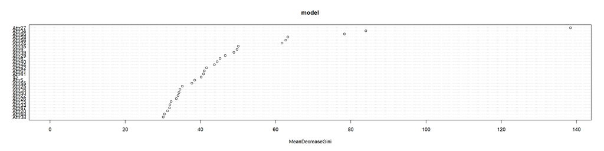

```r
varImpPlot(model)
```

# Predict on Train data

```r
pred_Train_rd = predict(model,
                     train_data[,setdiff(names(train_data), "target")],
                     type="response",
                     norm.votes=TRUE)
```

# Build confusion matrix and find accuracy

```r
cm_Train = table("actual"= train_data$target, "predicted" = pred_Train_rd);
accu_Train= sum(diag(cm_Train))/sum(cm_Train)
#rm(pred_Train_rd, cm_Train)
```

# Predicton Test Data

```r
pred_Test_rd = predict(model, test_data[,setdiff(names(test_data),
                                              "target")],
                    type="response",
                    norm.votes=TRUE)
```

# Build confusion matrix and find accuracy

```r
cm_Test = table("actual"=test_data$target, "predicted"=pred_Test_rd);
accu_Test= sum(diag(cm_Test))/sum(cm_Test)
#rm(pred_Test, cm_Test)
```

# Check the accuracy in train and test

```r
accu_Train
```

```
## [1] 0.9996874
```

```r
accu_Test
```

```
## [1] 0.9605107
```

# Build randorm forest using top 9 important attributes.

```r
top_Imp_Attr = as.character(rf_Imp_Attr$Attributes[1:9])
```

# Build the classification model using randomForest

```r
model_Imp = randomForest(target~.,
                         data=train_data[,c(top_Imp_Attr,"target")],
                         keep.forest=TRUE,ntree=50)
```

# Print and understand the model

```r
print(model_Imp)
```

```
##
## Call:
##  randomForest(formula = target ~ ., data = train_data[, c(top_Imp_Attr,      "target")], keep.forest = TRUE, ntree = 50)
##                Type of random forest: classification
##                      Number of trees: 50
## No. of variables tried at each split: 3
##
##         OOB estimate of  error rate: 3.51%
## Confusion matrix:
##       0   1 class.error
## 0 24271  94 0.003857993
## 1   803 420 0.656582175
```

# Important attributes

```r
model_Imp$importance
```

```
##        MeanDecreaseGini
## Attr27         328.5925
## Attr34         385.3800
## Attr46         251.1152
## Attr58         252.9222
## Attr56         241.1253
## Attr24         228.2003
## Attr35         203.9537
## Attr9          236.9829
## Attr39         196.9732
```

# Predict on Train data

```r
pred_Train_rd_attr = predict(model_Imp, train_data[,top_Imp_Attr],
                     type="response", norm.votes=TRUE)
```

# Build confusion matrix and find accuracy

```r
cm_Train = table("actual" = train_data$target,
                 "predicted" = pred_Train_rd_attr);
accu_Train_Imp = sum(diag(cm_Train))/sum(cm_Train)
#rm(pred_Train, cm_Train)
```

# Predicton Test Data

```r
pred_Test_rd_attr = predict(model_Imp, test_data[,top_Imp_Attr],
                    type="response", norm.votes=TRUE)
```

# Build confusion matrix and find accuracy

```r
cm_Test = table("actual" = test_data$target,
                "predicted" = pred_Test_rd_attr);
accu_Test_Imp = sum(diag(cm_Test))/sum(cm_Test)
#rm(pred_Test, cm_Test)
```

# Print the accuracy

```r
accu_Train
```

```
## [1] 0.9996874
```

```r
accu_Test
```

```
## [1] 0.9605107
```

```r
accu_Train_Imp
```

```
## [1] 0.9998437
```

```r
accu_Test_Imp
```

```
## [1] 0.9652531
```

# Top Important attributes

```r
top_Imp_Attr = as.character(rf_Imp_Attr$Attributes[1:9])
set.seed(123)
x <- train_data[,!(names(train_data) %in% c("target"))]
y <- train_data[,(names(train_data) %in% c("target"))]
str(y)
```

```
##  Factor w/ 2 levels "0","1": 1 1 1 1 1 1 1 1 1 1 ...
```

```
## mtry = 8  OOB error = 4.01%
## Searching left ...
## mtry = 4     OOB error = 4.61%
## -0.1489776 0.05
## Searching right ...
## mtry = 16    OOB error = 3.6%
## 0.104187 0.05
## mtry = 32    OOB error = 3.22%
## 0.1043478 0.05
## mtry = 64    OOB error = 3.12%
## 0.03033981 0.05
```

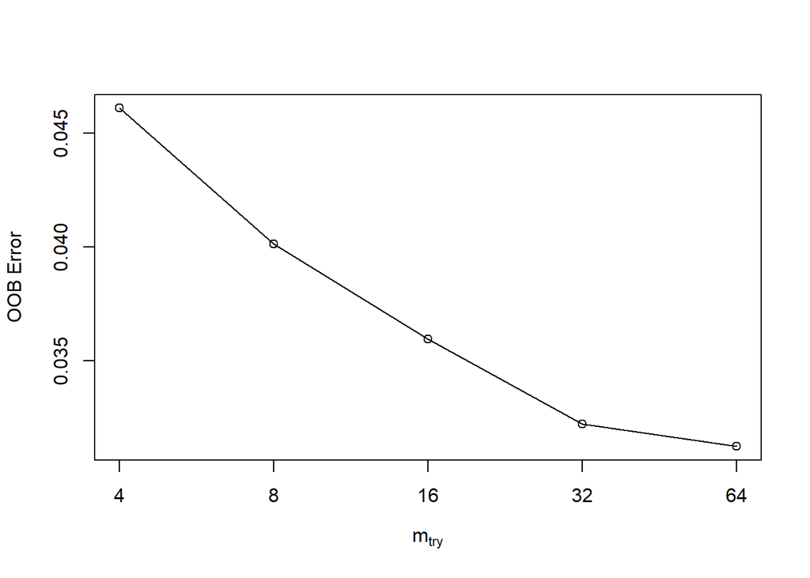

```r
tunedmodel <-tuneRF(x, y, ntreeTry = 50, trace=TRUE, plot=TRUE, doBest = TRUE)
```

# Print the tuned model

```r
print(tunedmodel)
```

```
##
## Call:
##  randomForest(x = x, y = y, mtry = res[which.min(res[, 2]), 1])
##                Type of random forest: classification
##                      Number of trees: 500
## No. of variables tried at each split: 64
##
##         OOB estimate of  error rate: 3.14%
## Confusion matrix:
##       0   1 class.error
## 0 24296  69 0.002831931
## 1   734 489 0.600163532
```

```r
tunedmodel$importance
```

```
##        MeanDecreaseGini
## ID            47.104366
## Attr1         10.947148
## Attr2          9.820054
## Attr3         18.484756
## Attr4         26.354043
## Attr5         84.159971
## Attr6         56.048337
## Attr7          8.167342
## Attr8         10.221930
## Attr9         25.189081
## Attr10         9.617765
## Attr11        15.136207
## Attr12        15.358034
## Attr13        20.008260
## Attr14         7.872529
## Attr15        32.708267
## Attr16        13.789300
## Attr17         8.974876
## Attr18         7.895996
## Attr19        15.693212
## Attr20        24.159767
## Attr21        32.812584
## Attr22        22.087733
## Attr23        11.941566
## Attr24        68.233731
## Attr25        31.536609
## Attr26        20.918064
## Attr27       137.914810
## Attr28        16.296122
## Attr29        32.463563
## Attr30        25.805018
## Attr31        12.835974
## Attr32        16.292146
## Attr33        21.983803
## Attr34       346.724633
## Attr35        65.423062
## Attr36        28.826141
## Attr37        27.784577
## Attr38        20.722892
```

[output cut: 11 more lines]

```
## Attr50        20.985341
## Attr51        15.689752
## Attr52        11.649343
## Attr53        15.888776
## Attr54        16.258606
## Attr55        35.781258
## Attr56       115.569227
## Attr57        27.162836
## Attr58       101.198686
## Attr59        19.776938
## Attr60        26.795227
## Attr61        46.713272
## Attr62        12.471954
## Attr63        13.754349
## Attr64        22.334851
```

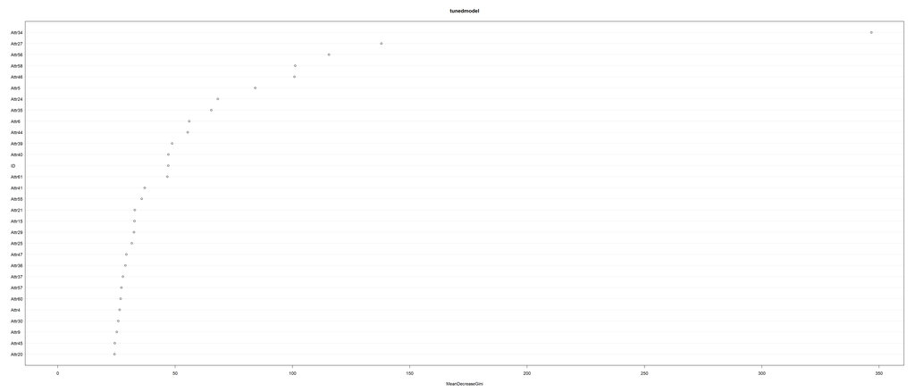

```r
varImpPlot(tunedmodel)
```

# Predict on Train data

```r
pred_Train_rd_tune = predict(tunedmodel, train_data,
                     type="response", norm.votes=TRUE)
```

# Build confusion matrix and find accuracy

```r
cm_Train = table("actual" = train_data$target,
                 "predicted" = pred_Train_rd_tune);
accu_Train = sum(diag(cm_Train))/sum(cm_Train)
#rm(pred_Train, cm_Train)
```

# Predicton Test Data

```r
pred_Test_rd_tune = predict(tunedmodel, test_data,
                    type="response", norm.votes=TRUE)
```

# Build confusion matrix and find accuracy

```r
cm_Test = table("actual" = test_data$target,
                "predicted" = pred_Test_rd_tune);
accu_Test = sum(diag(cm_Test))/sum(cm_Test)
#rm(pred_Test, cm_Test)
```

# Get the accuracy on train and test

```r
accu_Train
```

```
## [1] 1
```

```r
accu_Test
```

```
## [1] 0.9690834
```